# Exchange rates and stock market

Yi-Fang Lo

7/15/2019

# Foreign currencies and Taiwan Stock market

## Objective: explore the relationship between Foreign currency exchange rates and Taiwan stock market performance

## Data source:Previous homework, Click [HERE](https://vladislav292.github.io/2019summer-datasciece/work2/work2.html) to learn more

```r
library(readr)
library(tidyverse)
data_merged <- read_csv("C:/Users/Maple/Documents/work3/data_merged.csv")
```

## USD exchange rate

First make a graph to visulaize the relationship between date and USD/NTD exchange rate

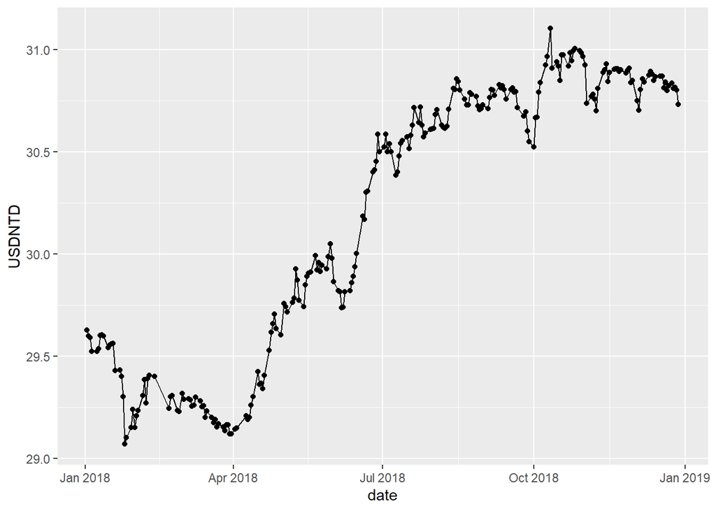

```r
ggplot(data = data_merged) + geom_line (mapping = aes (x= date, y=USDNTD))+ geom_point(mapping = aes (x=date, y=USDNTD))
```

Then make a graph to visulaize the relationship between date and Taiwan Stock Market Index

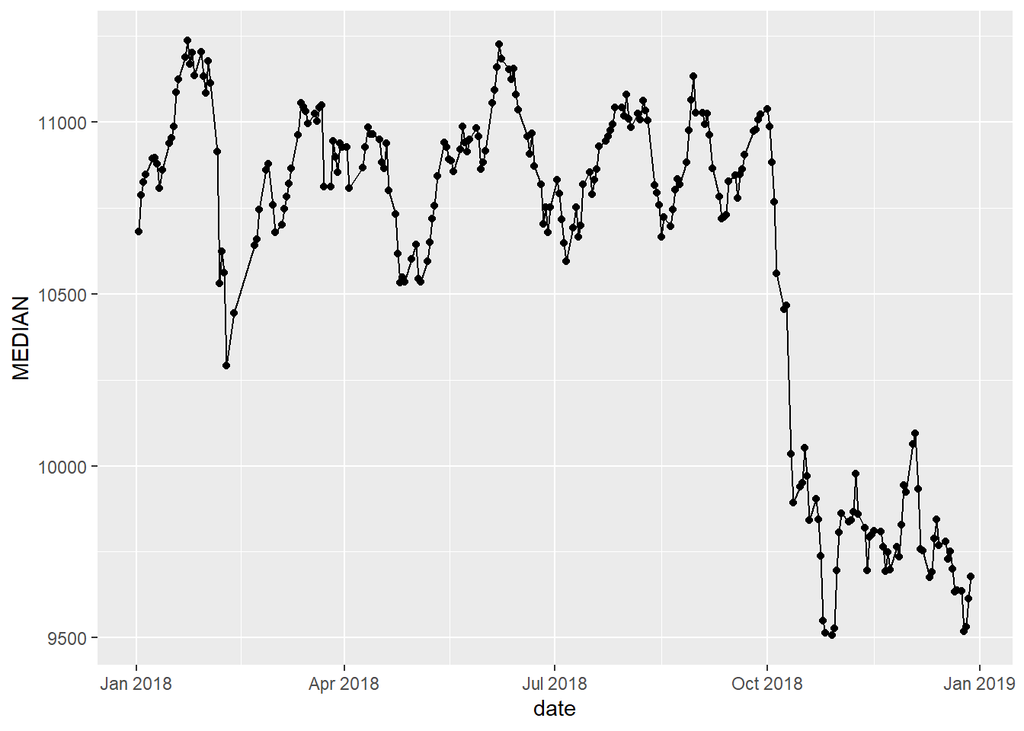

```r
ggplot(data = data_merged, mapping=aes(x= date, y = MEDIAN)) + geom_line()+geom_point()
```

Make a graph between USD/NTD exchnage rate and Taiwan Stock Index

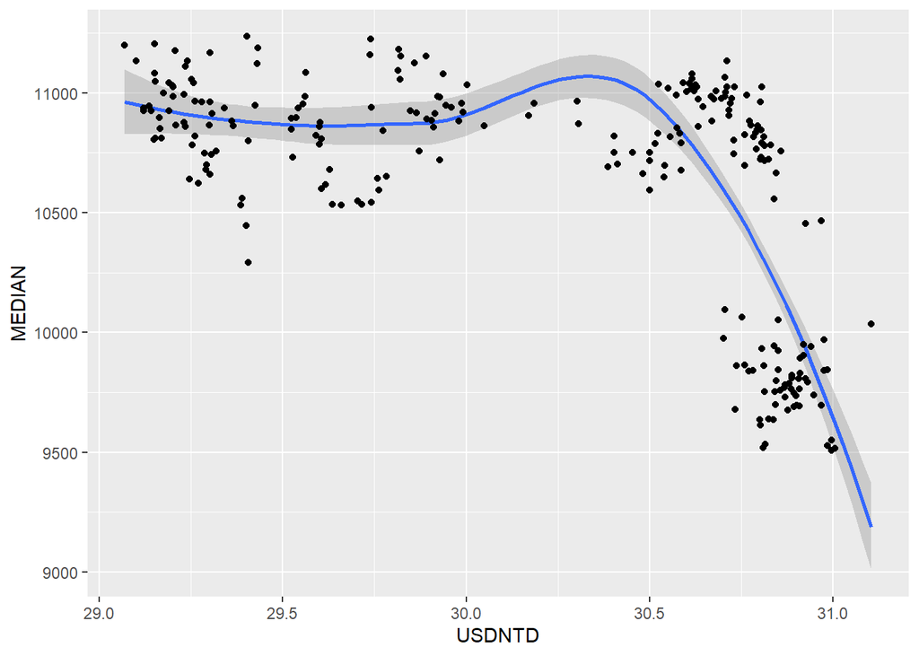

```r
ggplot(data = data_merged,mapping = aes(x= USDNTD, y=MEDIAN))+ geom_smooth()+ geom_point()
```

## RMB exchange rate

Make a graph to understade the relationship between date and RMB/NTD exchange rate

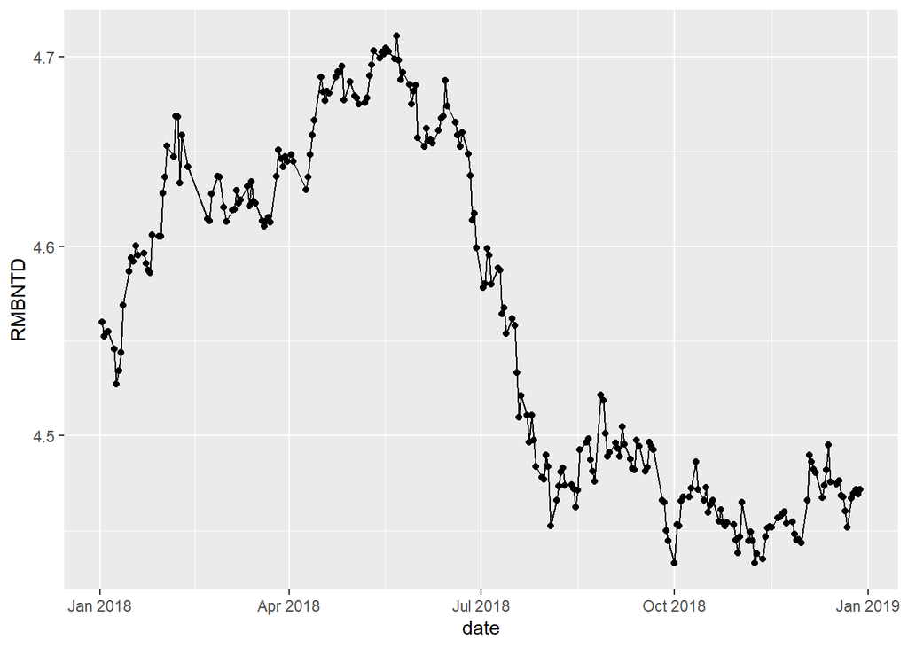

```r
ggplot(data = data_merged,mapping=aes(x=date,y=RMBNTD))+geom_point()+geom_line()
```

And then Make a graph base on RMB and Stock Martet Index

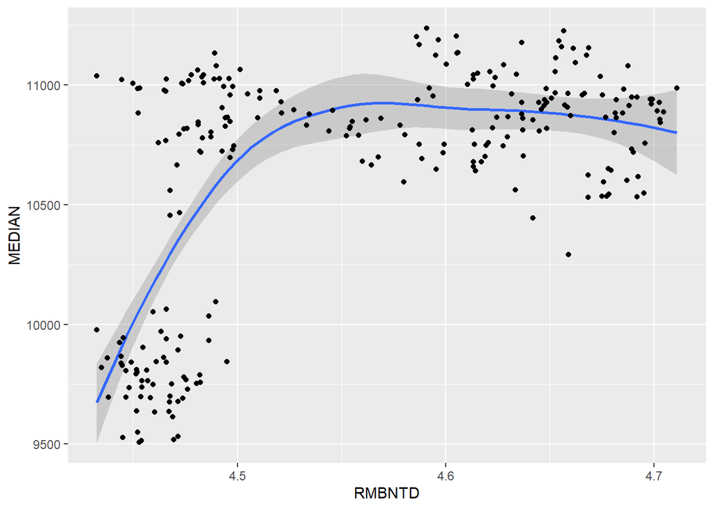

```r
ggplot(data = data_merged, mapping = aes (x = RMBNTD, y = MEDIAN)) + geom_smooth()+ geom_point()
```

## JPY exchange rate

Make a graph based on JPY/NTD and date, however, since we don’t have JPY/NTD exchange rate, thus, we must calculate the value through USD/NTD exchange rate and USD/JPY exchange rate

```r
data_new <- data_merged %>% mutate(JPYNTD = USDNTD/USDJPY)
```

After we aquire the exchange rate,plot the date-JPY graph

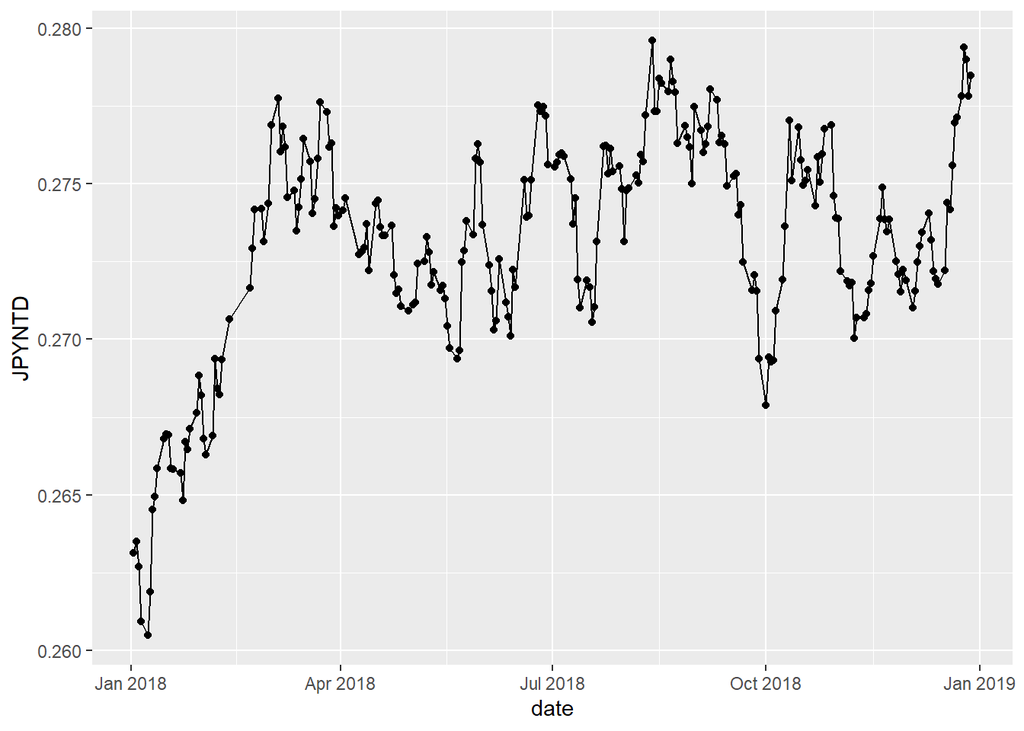

```r
ggplot(data = data_new, mapping = aes (x= date , y=JPYNTD))+ geom_line()+geom_point()
```

Make a graph to visualize the relation between JPY/NTD and Taiwan Stock Index

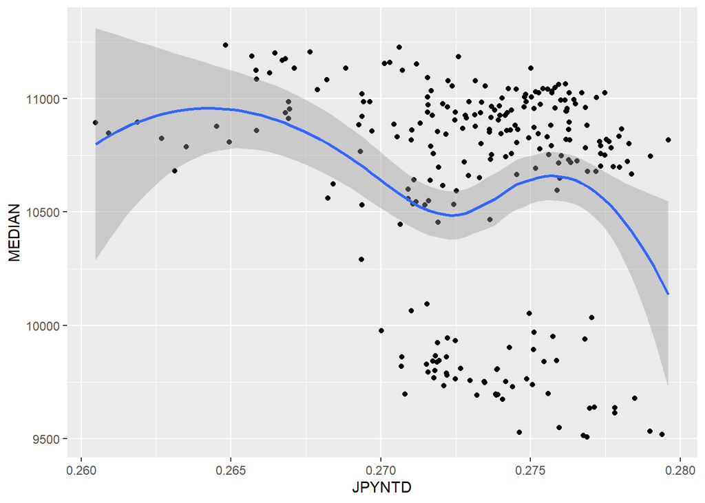

```r
ggplot(data = data_new, mapping = aes(x= JPYNTD, y= MEDIAN))+ geom_point()+ geom_smooth()
```

After these analysis, let us see if we can find something new by intergrating the excchange rate to date graph with index to date graph

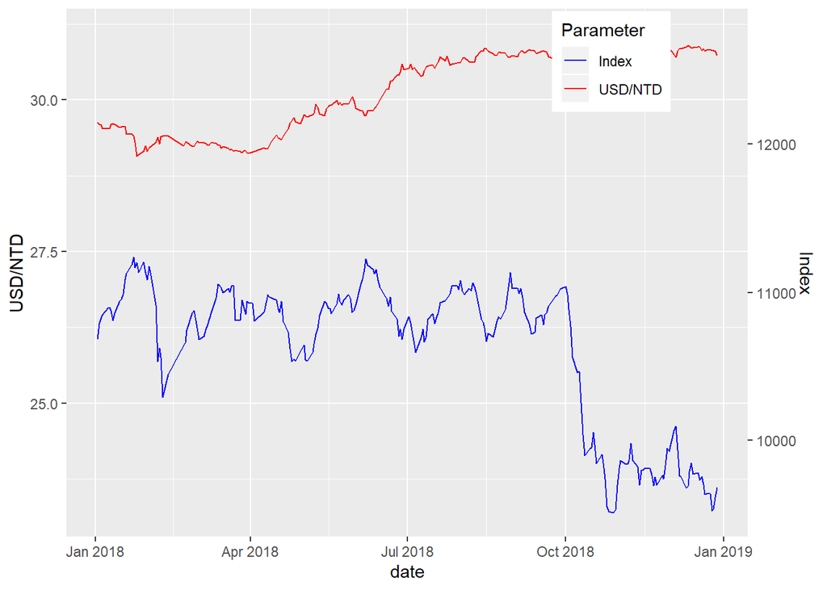

```r
p <- ggplot(data_new, aes(x = date))
p <- p + geom_line(aes(y=USDNTD, colour = "USD/NTD"))
p <- p + geom_line(aes(y=MEDIAN/410, colour = "Index"))
p <- p + scale_y_continuous(sec.axis = sec_axis(~.*410, name = "Index"))
p <- p + scale_colour_manual(values = c("blue", "red"))
p <- p + labs(y = "USD/NTD",x = "date",colour = "Parameter")
p <- p + theme(legend.position = c(0.8, 0.9))
p
```

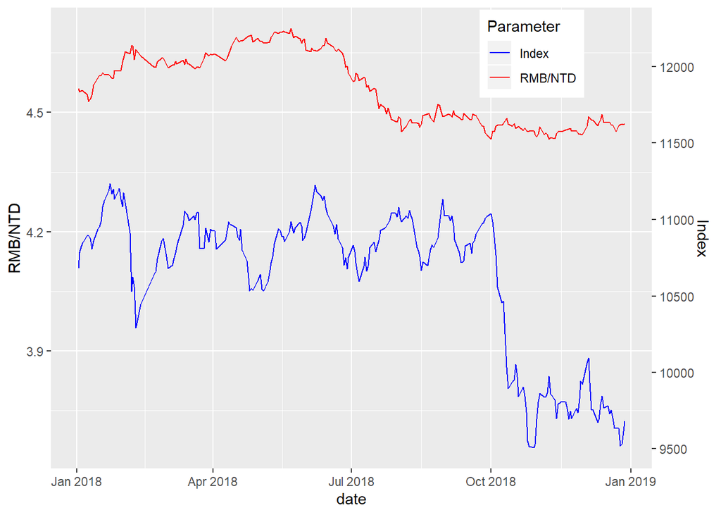

```r
q <- ggplot(data_new, aes(x = date))
q <- q + geom_line(aes(y=RMBNTD, colour = "RMB/NTD"))
q <- q + geom_line(aes(y=MEDIAN/2600, colour = "Index"))
q <- q + scale_y_continuous(sec.axis = sec_axis(~.*2600, name = "Index"))
q <- q + scale_colour_manual(values = c("blue", "red"))
q <- q + labs(y = "RMB/NTD",x = "date",colour = "Parameter")
q <- q + theme(legend.position = c(0.8, 0.9))
q
```

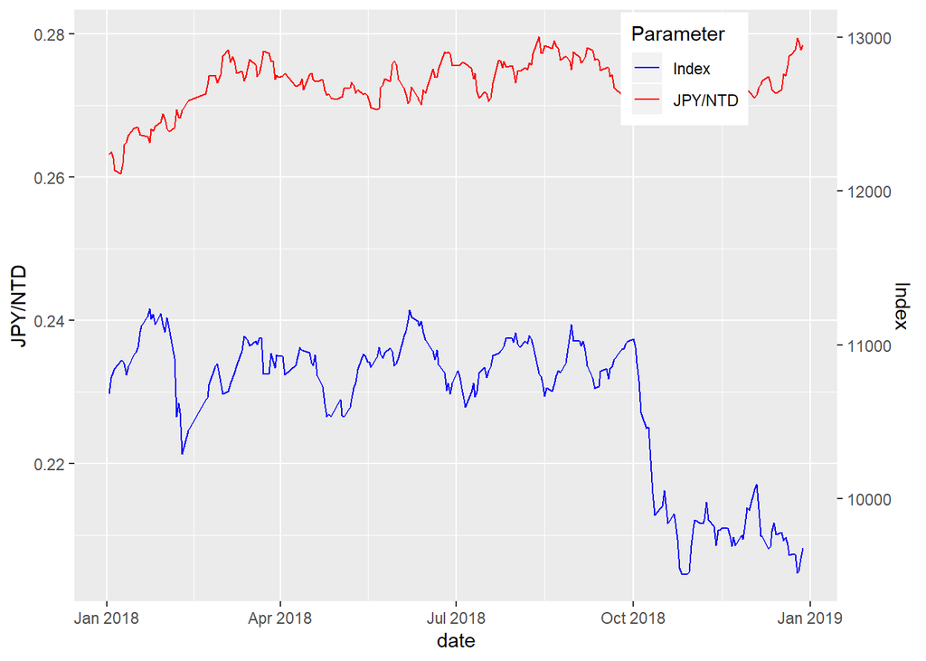

```r
r <- ggplot(data_new, aes(x = date))
r <- r + geom_line(aes(y=JPYNTD, colour = "JPY/NTD"))
r <- r + geom_line(aes(y=MEDIAN/46500, colour = "Index"))
r <- r + scale_y_continuous(sec.axis = sec_axis(~.*46500, name = "Index"))
r <- r + scale_colour_manual(values = c("blue", "red"))
r <- r + labs(y = "JPY/NTD",x = "date",colour = "Parameter")
r <- r + theme(legend.position = c(0.8, 0.9))
r
```

Lastly, let us do some statistics about currency exchange rates

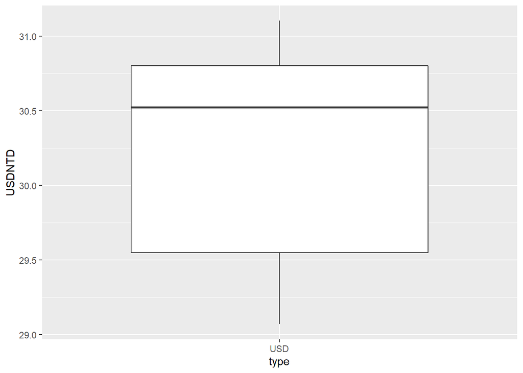

```r
USD <- data_new %>%　select(USDNTD)
JPY <- data_new %>%  select(JPYNTD)
RMB <- data_new %>%  select(RMBNTD)
dfUSD <- USD %>% mutate(type="USD")
dfJPY <- JPY %>% mutate(type="JPY")
dfRMB <- RMB %>% mutate(type="RMB")
ggplot(data = dfUSD,mapping = aes(x=type,y=USDNTD))+ geom_boxplot()
```

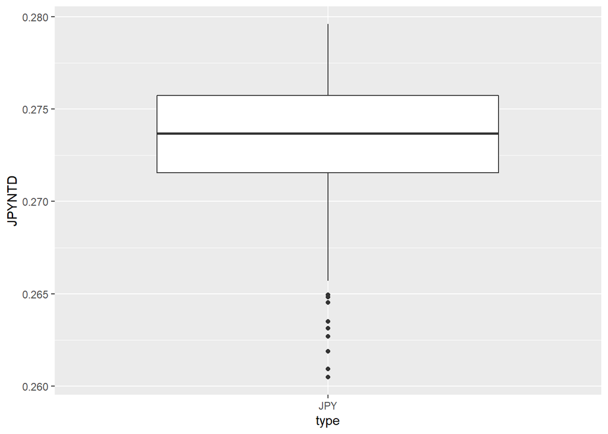

```r
ggplot(data = dfJPY,mapping = aes(x=type,y=JPYNTD))+ geom_boxplot()
```

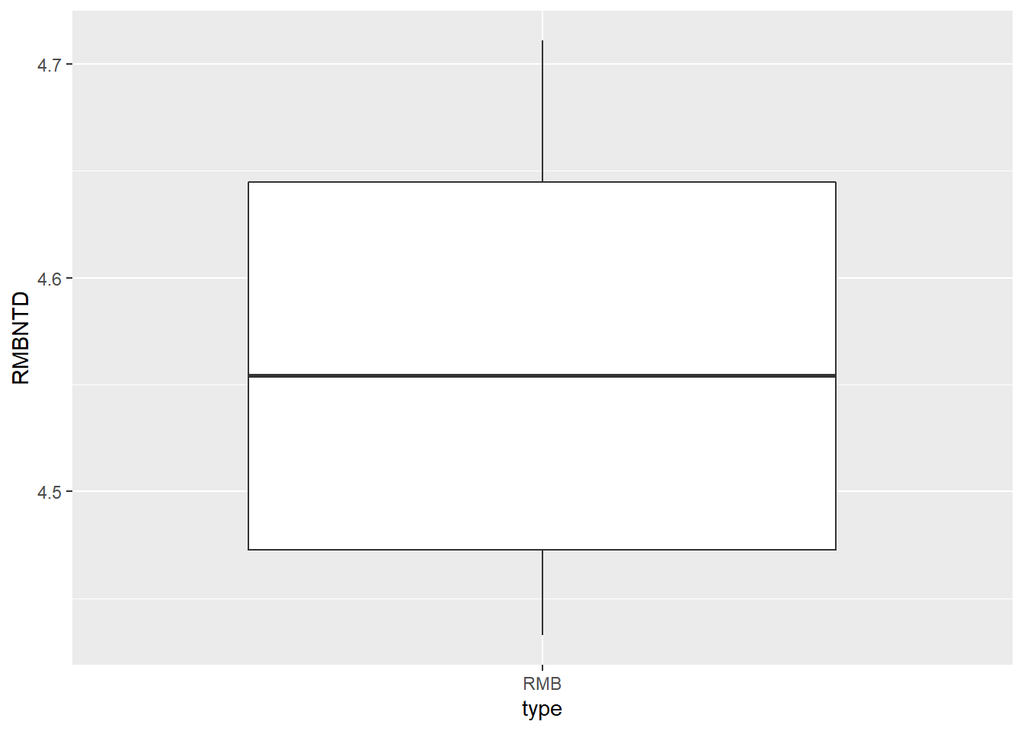

```r
ggplot(data = dfRMB,mapping = aes(x=type,y=RMBNTD))+ geom_boxplot()
```

## Conclusions

According to these little data we have, we may guess that * As USD/NTD>30.5, the Stock Market Index becomes really hard to predict and may drop suddenly as USD/NTD>30.75.  
* As RMB/NTD>4.5, the Stock Market Indext has a good chance to be higher than 10250. However, as RMB/NTD<4.5, the chance for the Index to be lower than 10000 is greater than that of be higher than 10000.  
* JPY/NTD exchange rate has little relationship with the Index.